# Chapter 1 Worked Problems

Load libraries

```r
library(ggplot2)
```

**Problem 1.**

**a)**

```r
# The number of phenotypic classes obtained (in general) is given by:
num_classes<-function(n){(2*n)+1}
n<-20 # The number of loci
num_classes(n)
```

```
## [1] 41
```

**b)** The probability of finding an individual among the offspring that is heterozygous at all 20 loci is the product of the probabilities at being heterozygous at 1 locus. N.B. We assume that they are unlinked (independent), and the parent is a heterozygote that is reproducing via selfing. Thus for a single locus the frequency of heterozygotes is 2/4 (0.5). So the frequency of heterozygotes at 20 loci is:

```r
0.5^n
```

```
## [1] 9.536743e-07
```

**c)** The probability of obtaining descendants with a phenotypic value of 10 can be obtained using the binomial theorem.

```r
n<-20
k<-10
p<-0.5
q<-1-p
# There are 2n alleles, we choose 10 of them and we want to kno how many have k = 10. This can be obtained with:
choose((2*n),k)*(p^k)*(q^((2*n)-k))
```

```
## [1] 0.0007709428
```

```r
# R also has a function for this
dbinom(x = k, prob = p,size=(2*n))
```

```
## [1] 0.0007709428
```

To get the full probability distribution we can compute the probabilities for all k = {0..40}. Again, we are mating two heterozygotes, so the allele frequencies are p = q = 0.5

```r
genotypic_values<-seq(0,40)
probabilities<-dbinom(x=genotypic_values,prob=0.5,size=(2*n))
```

Plot this data

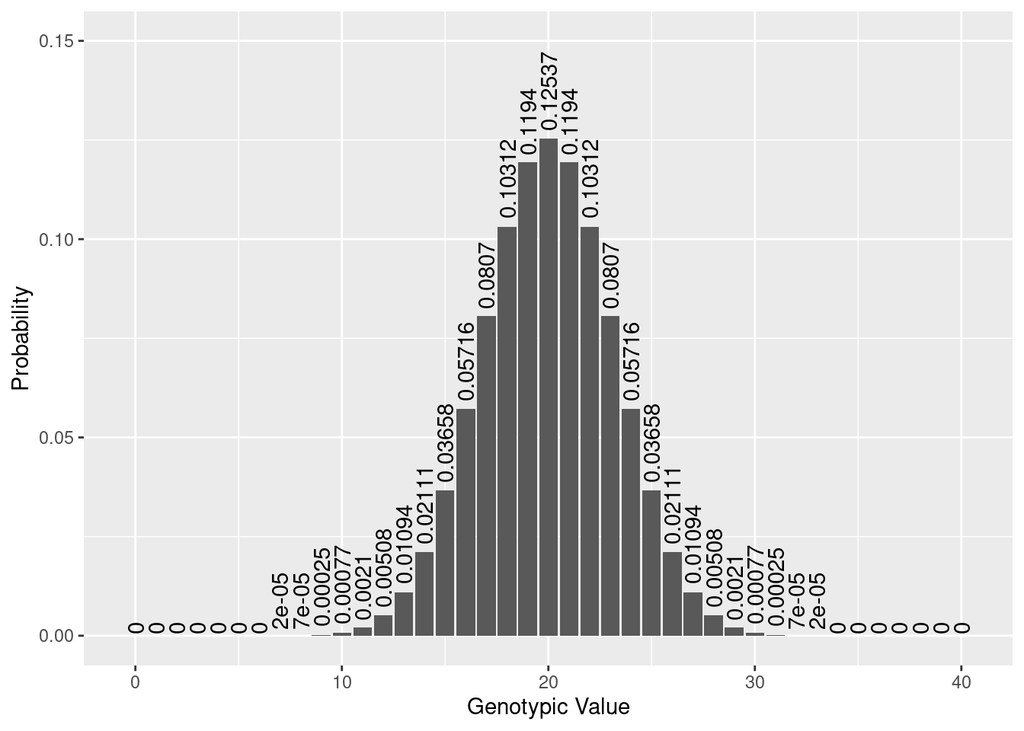

```r
ggplot()+
  geom_bar(aes(x=genotypic_values,y=probabilities),stat="identity")+
  geom_text(aes(x=genotypic_values,y=probabilities,label=as.character(round(probabilities,5))),hjust=-0.1,vjust=0.5,angle=90)+
  scale_y_continuous(limits=c(0,0.15))+
  xlab("Genotypic Value")+
  ylab("Probability")
```

**Problem 2.**

This is the data.

```r
bris<-c(24,24,21,21,21,20,19,19,18,24,
  23,25,22,24,22,22,18,20,22,28,
  23,27,23,20,23,21,26,27,27,28,
  26,26,24,26,27,26,20,22,21,18,
  18,21,17,21,18,20,23,22,34,22)
```

The phenotypic variance can be obtained simply from the phenotypic data. And we assume Vg = 4

```r
Vp<-var(bris)
Vg<-4
Ve<-Vp-Vg
```

Coefficients of variation for both P and G can be obtained with the mean of the phenotypic data. Since we assume that the mean of the genotypic values is the same as the mean of the phenotypic values.

```r
CVp<-sqrt(Vp)/(mean(bris))
CVg<-sqrt(Vg)/(mean(bris))
cat("Ve = ",Ve, ", CVp = ",CVp, ", CVg = ",CVg,"\n")
```

```
## Ve =  7.364898 , CVp =  0.1486414 , CVg =  0.08818342
```

**Self Assessment Questions:** 1. False 2. True 3. False 4. False 5. True 6. True 7. False 8. False 9. True 10. True